# Extended vignette for **EEAaq: Handle Air Quality Data from the European Environment Agency Data Portal**

# EEAaq summary

This function aims to describe the dataset that has been previously imported, both at a global level, which means considering the complete set of time stamps and monitoring stations in the dataset, and at the station-specific level, where summary statistics and information are grouped by monitoring station.  
In addition to basic exploratory descriptive statistics (e.g., average pollutant concentration, variability, measures of skewness and kurtosis), the function provides information about the gap length and the correlation between pollutants if at least two pollutants are considered simultaneously.  
The `EEAaq_summary` function receives as input an `EEAaq_df` object, i.e. the output of the EEAaq get data function.

### Compute the descriptive statistics

```r
summ <- EEAaq_summary(data = data)
```

```
## The dataset contains:
##  ** 155216 total observations
##  ** 16 stations
##  ** 9503 time stamps: from 2024-01-01 01:00:00 to 2025-01-31
```

### Print screen the global statsitics

```r
summ$Summary
```

| Pollutant | NA_count | NA_perc | negative_count | min | mean | max | sd |
| --- | --- | --- | --- | --- | --- | --- | --- |
| PM10 | 147548 | 95.059788 | 0 | 0.10000 | 36.91599 | 758.7079 | 33.29175 |
| NO2 | 8283 | 5.336434 | 0 | 0.03452 | 30.75084 | 158.3457 | 19.27253 |

### Print screen the station-specific statsitics

```r
summ$Summary_byStat$Mean_byStat
```

| AirQualityStationEoICode | AirQualityStationName | PM10 | NO2 |
| --- | --- | --- | --- |
| IT0477A | MILANO - V.LE MARCHE | 36.91599 | 30.75084 |
| IT0480A | SESTO S.GIOVANNI | 36.91599 | 30.75084 |
| IT0592A | RHO | 36.91599 | 30.75084 |
| IT0694A | CINISELLO B. | 36.91599 | 30.75084 |
| IT0705A | MILANO - VERZIERE | 36.91599 | 30.75084 |
| IT0706A | LIMITO | 36.91599 | 30.75084 |
| IT0761A | MILANO - V.LE LIGURIA | 36.91599 | 30.75084 |
| IT1010A | MAGENTA | 36.91599 | 30.75084 |
| IT1016A | MILANO - SENATO | 36.91599 | 30.75084 |
| IT1174A | MOTTA VISCONTI | 36.91599 | 30.75084 |

[output cut: 6 more lines]

### Print screen the linear correlation matrix

```r
summ$Corr_Matrix
```

| AirQualityStationEoICode | AirQualityStationName | PM10_NO2 | NO2_PM10 |
| --- | --- | --- | --- |
| IT0477A | MILANO - V.LE MARCHE | 0.34603662 | 0.34603662 |
| IT0480A | SESTO S.GIOVANNI | NA | NA |
| IT0592A | RHO | NA | NA |
| IT0694A | CINISELLO B. | NA | NA |
| IT0705A | MILANO - VERZIERE | 0.27232803 | 0.27232803 |
| IT0706A | LIMITO | 0.39495881 | 0.39495881 |
| IT0761A | MILANO - V.LE LIGURIA | NA | NA |
| IT1010A | MAGENTA | 0.20268043 | 0.20268043 |
| IT1016A | MILANO - SENATO | 0.47588565 | 0.47588565 |
| IT1174A | MOTTA VISCONTI | NA | NA |

[output cut: 6 more lines]

# EEAaq time aggregate

Recall that most pollutants are monitored by EEA on a hourly or daily basis, posing challenges for interpretation and representation. The `EEAaq_time_aggregate` function simplifies this by aggregating data into annual, monthly, weekly, daily, or hourly intervals, generating summary statistics for each station in an `EEAaq_taggr_df` object.

```r
t_aggr <- EEAaq_time_aggregate(
  data = data,
  frequency = "monthly",
  aggr_fun = c("min", "max", "mean", "median" )
)
```

### Print screen of the aggregated (monthly) data

```r
t_aggr$TimeAggr
```

| AirQualityStationEoICode | AirQualityStationName | Date | PM10_min | PM10_max | PM10_mean | PM10_median | NO2_min | NO2_max | NO2_mean | NO2_median |
| --- | --- | --- | --- | --- | --- | --- | --- | --- | --- | --- |
| IT0477A | MILANO - V.LE MARCHE | 2024-01-01 | 16.921900 | 112.22112 | 49.242047 | 47.24920 | 25.143480 | 110.00615 | 57.844133 | 55.854220 |
| IT0477A | MILANO - V.LE MARCHE | 2024-02-01 | 8.542330 | 118.68048 | 53.575673 | 48.05603 | 11.033630 | 99.98540 | 53.929162 | 52.724970 |
| IT0477A | MILANO - V.LE MARCHE | 2024-03-01 | 1.735440 | 64.64864 | 24.437234 | 21.28715 | 6.972540 | 92.07742 | 35.898977 | 35.183030 |
| IT0477A | MILANO - V.LE MARCHE | 2024-04-01 | 5.979680 | 47.17052 | 22.570897 | 20.66360 | 3.771600 | 117.52406 | 39.577049 | 37.823670 |
| IT0477A | MILANO - V.LE MARCHE | 2024-05-01 | 6.978330 | 43.91614 | 17.088156 | 16.48101 | 11.491200 | 107.97184 | 35.293836 | 33.801750 |
| IT0477A | MILANO - V.LE MARCHE | 2024-06-01 | 7.041480 | 54.90368 | 20.486428 | 17.38782 | 3.217800 | 93.28490 | 26.413918 | 23.636070 |
| IT0477A | MILANO - V.LE MARCHE | 2024-07-01 | 11.616750 | 42.92955 | 24.585507 | 26.06446 | 1.686070 | 108.69659 | 22.845213 | 19.459810 |
| IT0477A | MILANO - V.LE MARCHE | 2024-08-01 | 15.619180 | 37.38387 | 25.738479 | 26.20088 | 1.570640 | 87.74293 | 23.527703 | 20.044095 |
| IT0477A | MILANO - V.LE MARCHE | 2024-09-01 | 6.825960 | 41.61078 | 20.362493 | 19.12720 | 5.683340 | 91.06837 | 32.725926 | 31.063190 |
| IT0477A | MILANO - V.LE MARCHE | 2024-10-01 | 8.952620 | 66.96200 | 31.013814 | 26.11202 | 7.145030 | 86.25659 | 33.323090 | 33.214220 |

[output cut: 198 more lines]

### Print screen of the PM$_{10}$ aggregated data only

```r
t_aggr$TimeAggr_byPollutant$PM10
```

| AirQualityStationEoICode | AirQualityStationName | Date | min | max | mean | median |
| --- | --- | --- | --- | --- | --- | --- |
| IT0477A | MILANO - V.LE MARCHE | 2024-01-01 | 16.921900 | 112.22112 | 49.242047 | 47.24920 |
| IT0477A | MILANO - V.LE MARCHE | 2024-02-01 | 8.542330 | 118.68048 | 53.575673 | 48.05603 |
| IT0477A | MILANO - V.LE MARCHE | 2024-03-01 | 1.735440 | 64.64864 | 24.437234 | 21.28715 |
| IT0477A | MILANO - V.LE MARCHE | 2024-04-01 | 5.979680 | 47.17052 | 22.570897 | 20.66360 |
| IT0477A | MILANO - V.LE MARCHE | 2024-05-01 | 6.978330 | 43.91614 | 17.088156 | 16.48101 |
| IT0477A | MILANO - V.LE MARCHE | 2024-06-01 | 7.041480 | 54.90368 | 20.486428 | 17.38782 |
| IT0477A | MILANO - V.LE MARCHE | 2024-07-01 | 11.616750 | 42.92955 | 24.585507 | 26.06446 |
| IT0477A | MILANO - V.LE MARCHE | 2024-08-01 | 15.619180 | 37.38387 | 25.738479 | 26.20088 |
| IT0477A | MILANO - V.LE MARCHE | 2024-09-01 | 6.825960 | 41.61078 | 20.362493 | 19.12720 |
| IT0477A | MILANO - V.LE MARCHE | 2024-10-01 | 8.952620 | 66.96200 | 31.013814 | 26.11202 |

[output cut: 198 more lines]

# EEAaq_idw_map

To enable quick and intuitive visual analysis, the `EEAaq_idw_map` function provides spatial interpolation maps using the Inverse Distance Weighting (IDW) method (Shepard, 1968). This technique estimates the value of a variable at unknown locations by calculating a weighted average of known values, with weights inversely proportional to the distance from known points. Closer points contribute more heavily to the estimate, making it a practical approach for interpolating geolocated air quality data.

```r
EEAaq::EEAaq_idw_map(data = t_aggr, pollutant = "NO2", aggr_fun = "mean",
               distinct = TRUE, gradient = FALSE,
               dynamic = FALSE,
              NUTS_filler = "NUTS3", NUTS_extborder = "NUTS2")
```

```
## Map initialization started at 2026-02-10 12:10:28.213297
## Map initialization ended at 2026-02-10 12:10:38.390465
## Computing IDW interpolation started at 2026-02-10 12:10:38.390706
## Computing IDW interpolation for: 2024-01-01, 1 of 13
## [inverse distance weighted interpolation]
## Computing IDW interpolation for: 2024-02-01, 2 of 13
## [inverse distance weighted interpolation]
## Computing IDW interpolation for: 2024-03-01, 3 of 13
## [inverse distance weighted interpolation]
## Computing IDW interpolation for: 2024-04-01, 4 of 13
## [inverse distance weighted interpolation]
## Computing IDW interpolation for: 2024-05-01, 5 of 13
## [inverse distance weighted interpolation]
## Computing IDW interpolation for: 2024-06-01, 6 of 13
## [inverse distance weighted interpolation]
## Computing IDW interpolation for: 2024-07-01, 7 of 13
## [inverse distance weighted interpolation]
## Computing IDW interpolation for: 2024-08-01, 8 of 13
## [inverse distance weighted interpolation]
## Computing IDW interpolation for: 2024-09-01, 9 of 13
## [inverse distance weighted interpolation]
## Computing IDW interpolation for: 2024-10-01, 10 of 13
## [inverse distance weighted interpolation]
## Computing IDW interpolation for: 2024-11-01, 11 of 13
## [inverse distance weighted interpolation]
## Computing IDW interpolation for: 2024-12-01, 12 of 13
## [inverse distance weighted interpolation]
## Computing IDW interpolation for: 2025-01-01, 13 of 13
## [inverse distance weighted interpolation]
## Computing IDW interpolation ended at 2026-02-10 12:11:34.722376
```

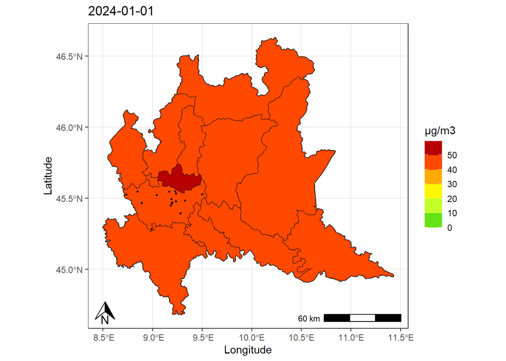

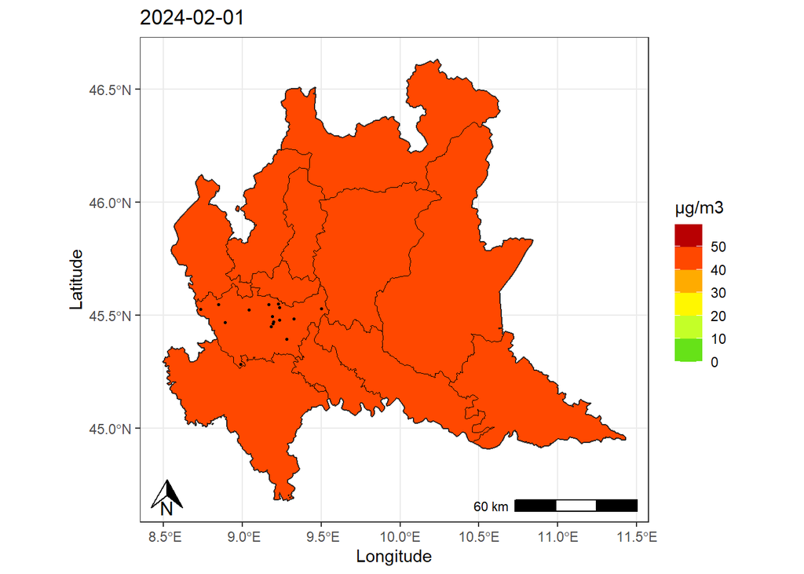

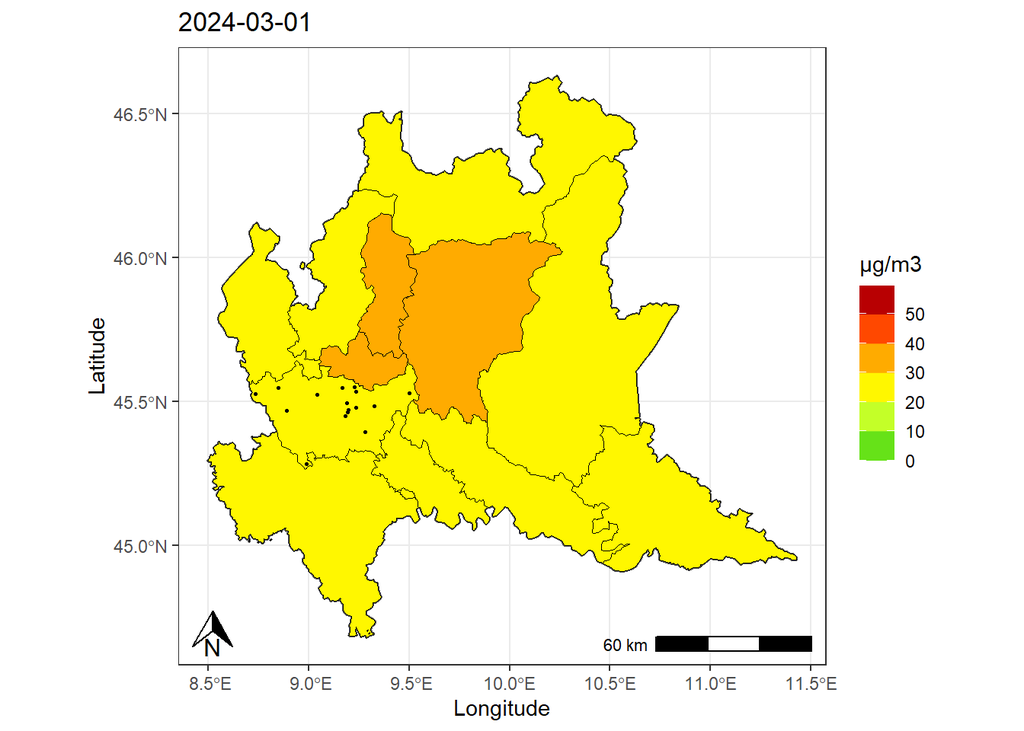

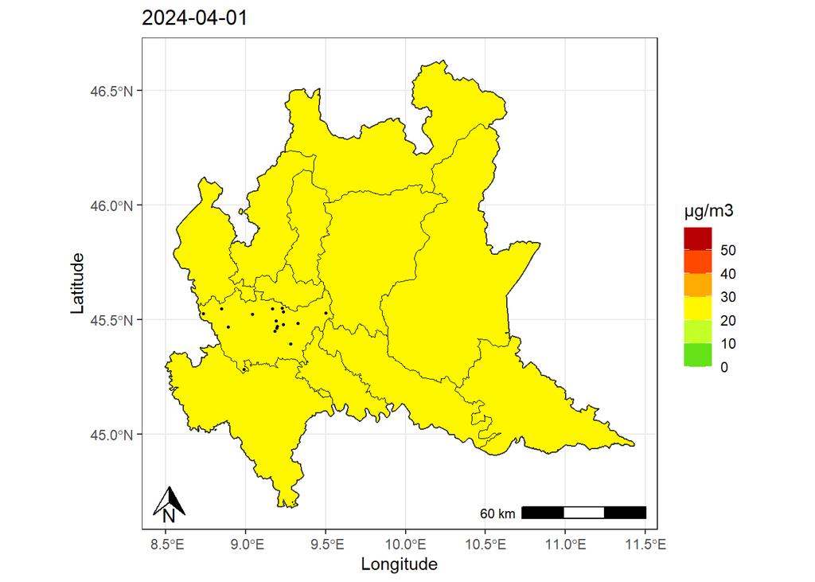

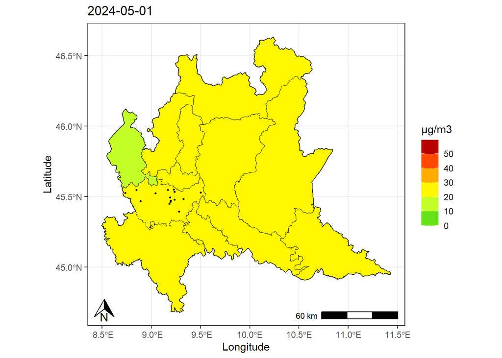

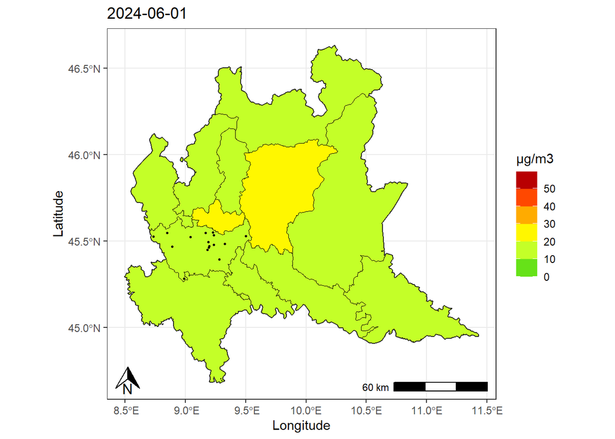

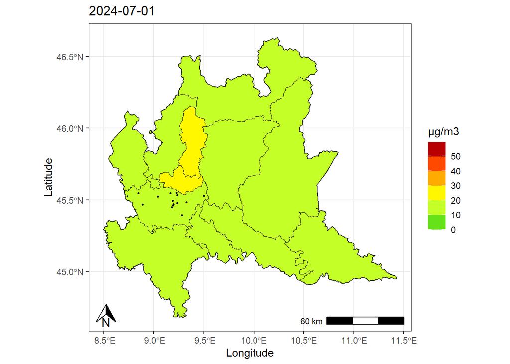

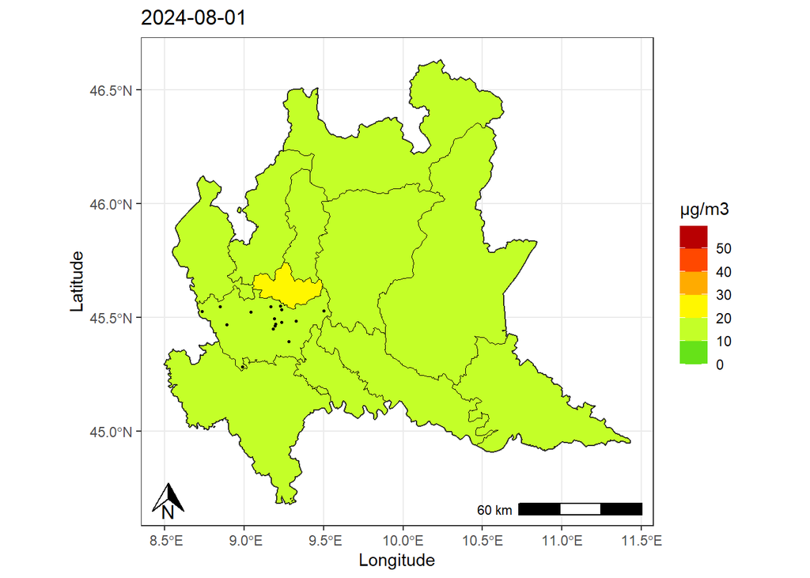

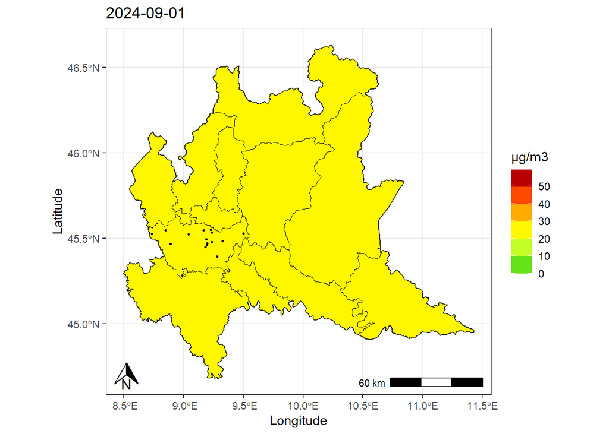

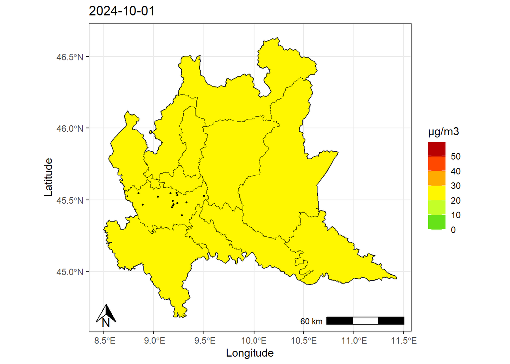

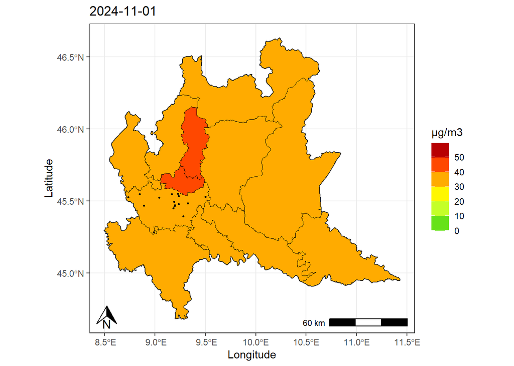

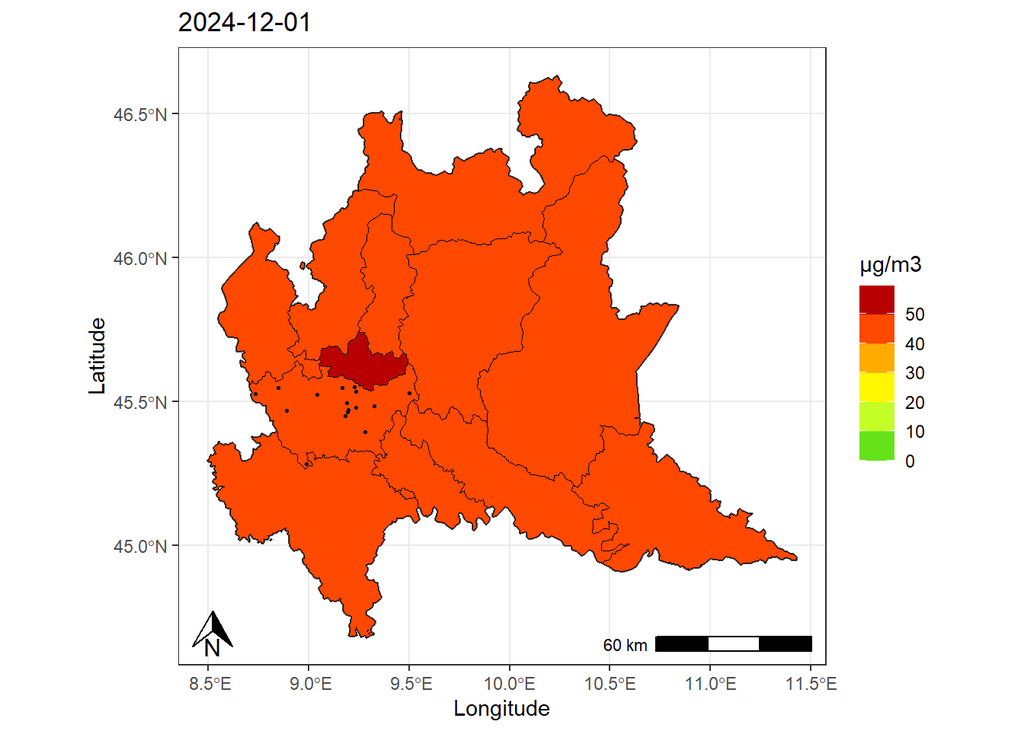

[1 more figures not shown]

```r
 t_aggr$TimeAggr_byPollutant$NO2
```

| AirQualityStationEoICode | AirQualityStationName | Date | min | max | mean | median |
| --- | --- | --- | --- | --- | --- | --- |
| IT0477A | MILANO - V.LE MARCHE | 2024-01-01 | 25.143480 | 110.00615 | 57.844133 | 55.854220 |
| IT0477A | MILANO - V.LE MARCHE | 2024-02-01 | 11.033630 | 99.98540 | 53.929162 | 52.724970 |
| IT0477A | MILANO - V.LE MARCHE | 2024-03-01 | 6.972540 | 92.07742 | 35.898977 | 35.183030 |
| IT0477A | MILANO - V.LE MARCHE | 2024-04-01 | 3.771600 | 117.52406 | 39.577049 | 37.823670 |
| IT0477A | MILANO - V.LE MARCHE | 2024-05-01 | 11.491200 | 107.97184 | 35.293836 | 33.801750 |
| IT0477A | MILANO - V.LE MARCHE | 2024-06-01 | 3.217800 | 93.28490 | 26.413918 | 23.636070 |
| IT0477A | MILANO - V.LE MARCHE | 2024-07-01 | 1.686070 | 108.69659 | 22.845213 | 19.459810 |
| IT0477A | MILANO - V.LE MARCHE | 2024-08-01 | 1.570640 | 87.74293 | 23.527703 | 20.044095 |
| IT0477A | MILANO - V.LE MARCHE | 2024-09-01 | 5.683340 | 91.06837 | 32.725926 | 31.063190 |
| IT0477A | MILANO - V.LE MARCHE | 2024-10-01 | 7.145030 | 86.25659 | 33.323090 | 33.214220 |

[output cut: 198 more lines]

```r
EEAaq::EEAaq_idw_map(
  data = t_aggr$TimeAggr_byPollutant$NO2 %>% dplyr::filter(Date %in% c("2024-01-01","2024-02-01")),
  pollutant = "NO2",
  aggr_fun = "max",
  distinct = TRUE,
  gradient = TRUE,
  idp = 2,NUTS_extborder = "NUTS2",NUTS_filler = "LAU"
)
```

```
## Map initialization started at 2026-02-10 12:11:42.295259
## Map initialization ended at 2026-02-10 12:11:53.754541
## Computing IDW interpolation started at 2026-02-10 12:11:53.754843
## Computing IDW interpolation for: 2024-01-01, 1 of 2
## [inverse distance weighted interpolation]
## Computing IDW interpolation for: 2024-02-01, 2 of 2
## [inverse distance weighted interpolation]
## Computing IDW interpolation ended at 2026-02-10 12:12:05.170134
```

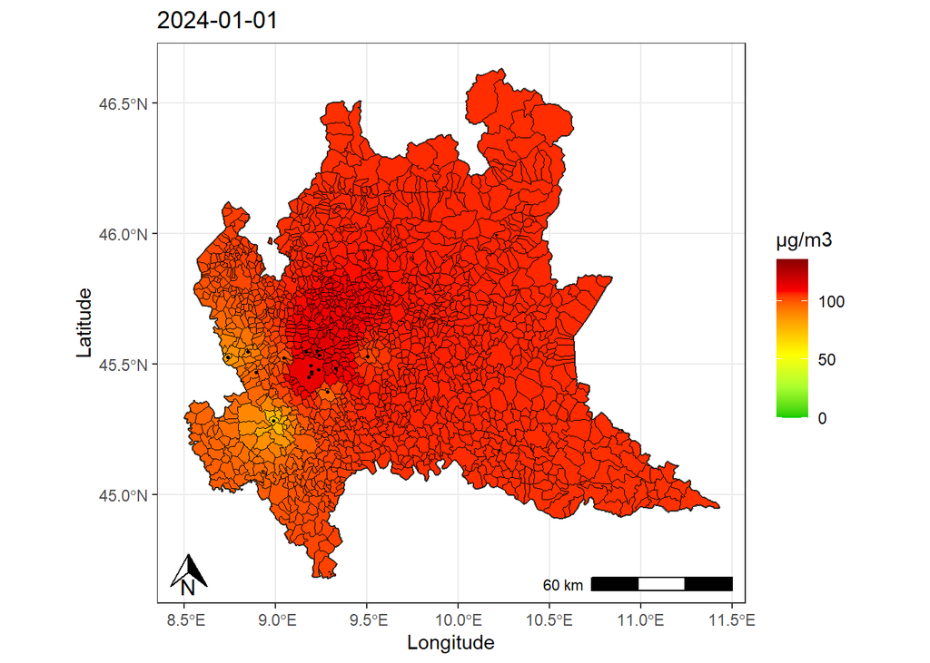

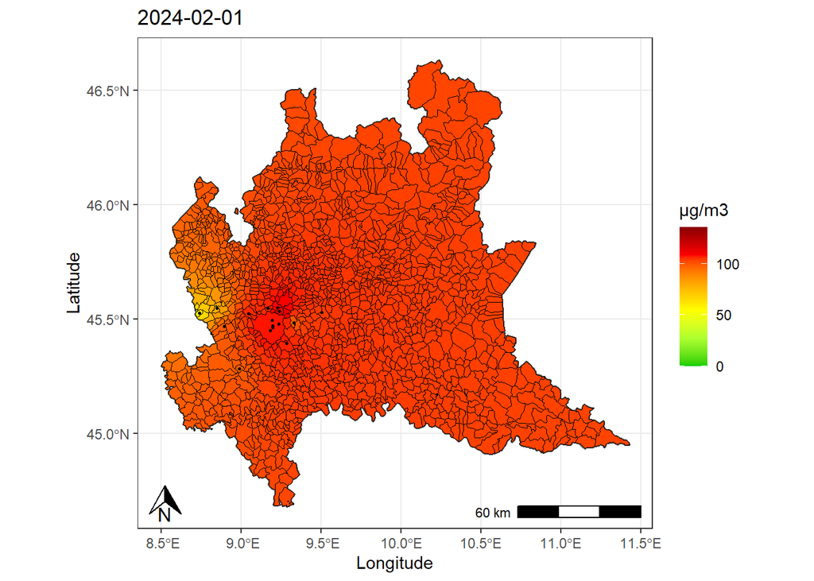